# Project 2 Question 3

Luke Sturgeon  
Stat 517  
Due Date: 10/29/18

#### Load Packages and Data

Packages and data are loaded but not inlcuded in output to save time and space in the report.

Pre-processing the data so that “tm” package can vectorize the bible.

```r
dir.create(paste(getwd(),"/","books",sep=""))
setwd(paste(file.path(getwd()),"/books",sep=""))
for (i in 1:nrow(ASV_Books)){
  titleoutput <- paste("book",i,".txt",sep="")
  write.table(ASV_Books[i,4], file=titleoutput, row.names=F, col.names=F)
}
setwd('..')
docs <- Corpus(DirSource(paste(getwd(),"/books",sep="")))
docs <- tm_map(docs, removePunctuation)
docs <- tm_map(docs,content_transformer(tolower))
docs <- tm_map(docs, removeNumbers)
docs <- tm_map(docs, removeWords, stopwords("english"))
docs <- tm_map(docs, removeWords,c("thou","thine","unto","hast","thy","saith","shal","shall","thee","said","will","upon"))
docs <- tm_map(docs, stripWhitespace)
docs <- tm_map(docs,stemDocument)
dtm <- DocumentTermMatrix(docs)
dim(dtm)
```

```
## [1]   66 9194
```

Because I’m curious, we look at the words that are said the least and most often in the bible.

```r
freq <- colSums(as.matrix(dtm))
ord <- order(freq,decreasing=TRUE)
print(freq[head(ord)])
```

```
## jehovah     god     son    king     man  israel
##    6882    4361    3522    2883    2646    2581
```

```r
freq[tail(ord)]
```

```
##     telaim   theeward       tohu whereabout     zelzah      zeror
##          1          1          1          1          1          1
```

I transform the Document Term Matrix into a matrix that I’m used to seeing and handling, then run PCA to minimize computation time for my overworked, ten year old laptop.

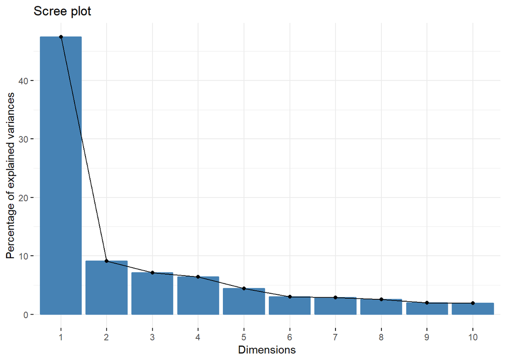

```r
dtm.m <- as.matrix(dtm)
dtm.m.prcomp <- prcomp(dtm.m)
fviz_eig(dtm.m.prcomp)
```

```r
pca.frame <- (dtm.m.prcomp$x[,1:28])
row.names(pca.frame)[1] <- "book01.txt"
row.names(pca.frame)[12] <- "book02.txt"
row.names(pca.frame)[23] <- "book03.txt"
row.names(pca.frame)[34] <- "book04.txt"
row.names(pca.frame)[45] <- "book05.txt"
row.names(pca.frame)[56] <- "book06.txt"
row.names(pca.frame)[64] <- "book07.txt"
row.names(pca.frame)[65] <- "book08.txt"
row.names(pca.frame)[66] <- "book09.txt"
pca.frame <- pca.frame[order(rownames(pca.frame)),]
test.sect <- ASV_Books[,2:3]
```

Scree plot showing how few dimensions we can use to explain the dataset. The following shows how the first 28 dimensions of the data explain 99% of the variance.

```r
get_eig(dtm.m.prcomp)[1:28,]
```

```
##        eigenvalue variance.percent cumulative.variance.percent
## Dim.1  82333.3683       47.4781354                    47.47814
## Dim.2  15819.0688        9.1221810                    56.60032
## Dim.3  12357.2585        7.1259029                    63.72622
## Dim.4  11135.8247        6.4215543                    70.14777
## Dim.5   7702.2460        4.4415561                    74.58933
## Dim.6   5171.2210        2.9820222                    77.57135
## Dim.7   5007.9191        2.8878530                    80.45920
## Dim.8   4393.6928        2.5336549                    82.99286
## Dim.9   3442.3231        1.9850406                    84.97790
## Dim.10  3264.1448        1.8822928                    86.86019
## Dim.11  2847.9880        1.6423130                    88.50251
## Dim.12  2436.1383        1.4048168                    89.90732
## Dim.13  1831.4107        1.0560963                    90.96342
## Dim.14  1711.8816        0.9871690                    91.95059
## Dim.15  1520.1656        0.8766146                    92.82720
## Dim.16  1373.5837        0.7920870                    93.61929
## Dim.17  1328.7123        0.7662116                    94.38550
## Dim.18  1198.8498        0.6913254                    95.07683
## Dim.19   940.6921        0.5424569                    95.61928
## Dim.20   891.8715        0.5143042                    96.13359
## Dim.21   806.9993        0.4653620                    96.59895
## Dim.22   773.7142        0.4461679                    97.04512
## Dim.23   698.7331        0.4029295                    97.44805
## Dim.24   593.3603        0.3421655                    97.79021
## Dim.25   543.0423        0.3131493                    98.10336
## Dim.26   460.6561        0.2656407                    98.36900
## Dim.27   349.0816        0.2013004                    98.57030
## Dim.28   302.7251        0.1745686                    98.74487
```

Now we see what clustering gets us.

```r
cluster <- Mclust(dtm.m.prcomp$x[,1:28])
summary(cluster)
```

```
## ----------------------------------------------------
## Gaussian finite mixture model fitted by EM algorithm
## ----------------------------------------------------
##
## Mclust VEI (diagonal, equal shape) model with 5 components:
##
##  log.likelihood  n  df       BIC       ICL
##       -7741.721 66 176 -16220.82 -16220.82
##
## Clustering table:
##  1  2  3  4  5
## 29  2  8 17 10
```

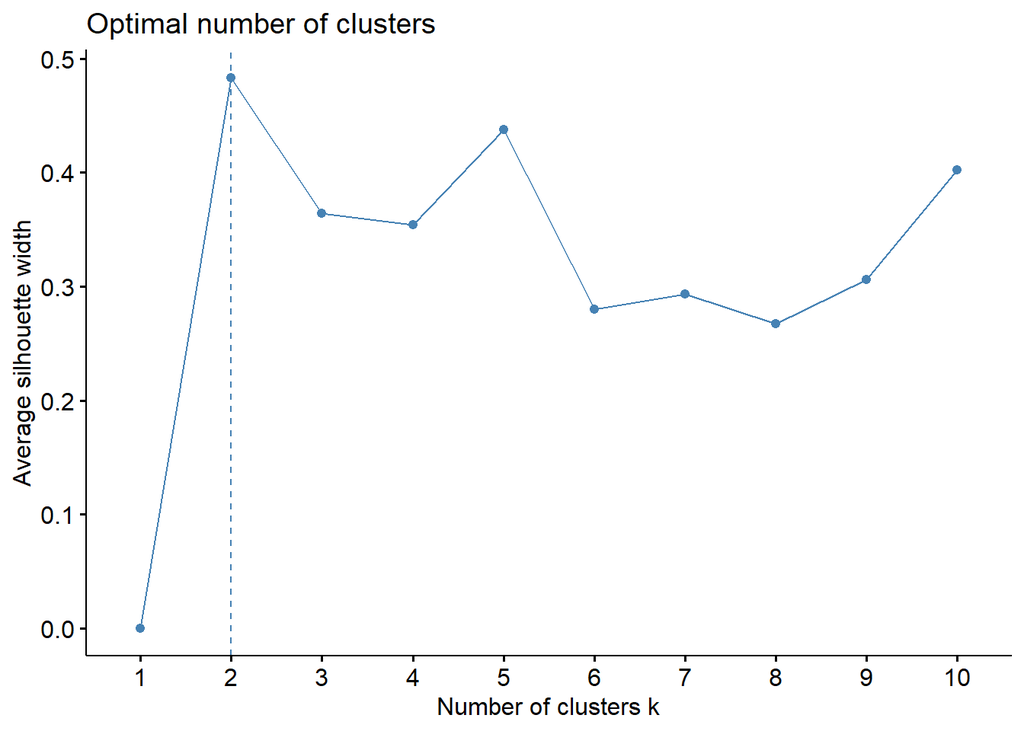

```r
fviz_nbclust(pca.frame[,-c(1:2)],kmeans)
```

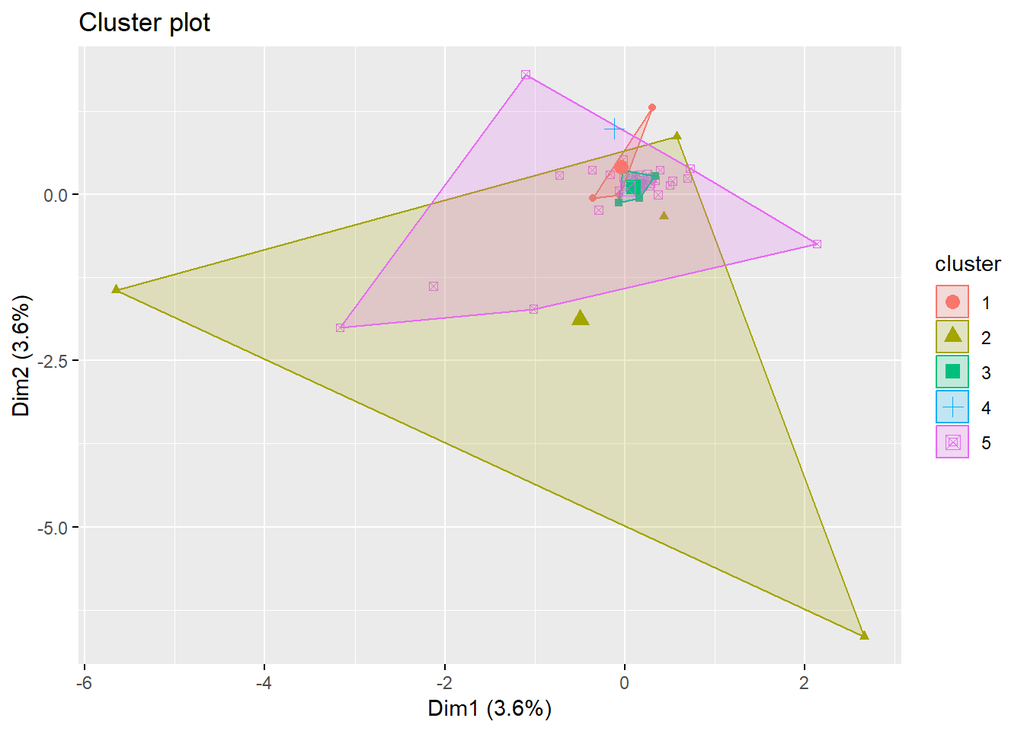

```r
k1 <- kmeans(pca.frame[,-c(1:2)], 5, nstart =25)
fviz_cluster(k1,pca.frame, geom = "point")
```

```r
ASV_Books$Testaments <- as.character(ASV_Books$Testaments)
for (i in 1:nrow(ASV_Books)){
         if (ASV_Books[i,2]=="OT") {
                 ASV_Books[i,2] <- 1
         } else {
                 ASV_Books[i,2] <- 2
         }
}
ASV_Books$Testaments <- as.factor(ASV_Books$Testaments)
table(k1$cluster, ASV_Books$Testaments)
```

```
##
##      1  2
##   1  3  0
##   2  4  0
##   3  0  5
##   4  1  0
##   5 31 22
```

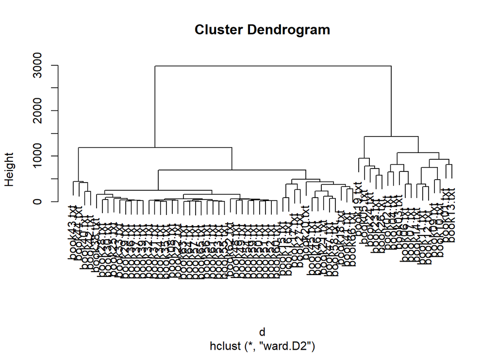

```r
d <- dist(pca.frame, method="euclidian")
hcluster <- hclust(d, method="ward.D2")
plot(hcluster)
```

```r
learned.testaments <- cutree(hcluster,k=2)
table(learned.testaments,ASV_Books$Testaments)
```

```
##
## learned.testaments  1  2
##                  1 17  0
##                  2 22 27
```

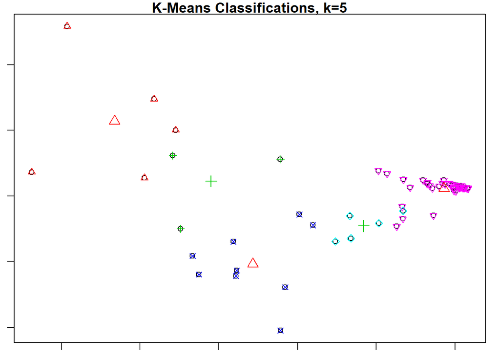

```r
par(mar=c(1,1,1,1))
k5 <- kmeans(pca.frame,5)
k2 <- kmeans(pca.frame,2)
k7 <- kmeans(pca.frame,7)
plot(pca.frame, main="K-Means Classifications, k=5")
points(pca.frame,pch=k5$cluster+1, col=k5$cluster+1)
points(k5$centers, col=2:3, pch=2:3, cex=1.5)
```

```r
table(k5$cluster,ASV_Books$Testaments)
```

```
##
##      1  2
##   1  5  0
##   2  3  0
##   3  9  0
##   4  0  5
##   5 22 22
```

```r
table(k2$cluster,ASV_Books$Testaments)
```

```
##
##      1  2
##   1 22 27
##   2 17  0
```

```r
table(k7$cluster,ASV_Books$Sections)
```

```
##
##     Apostles Gospels History Law Paul Prophets Wisdom
##   1        0       0       3   1    0        0      0
##   2        7       0       2   0   11       13      2
##   3        0       5       0   0    0        0      0
##   4        2       0       2   0    2        1      2
##   5        0       0       0   1    0        3      1
##   6        0       0       0   3    0        0      0
##   7        0       0       5   0    0        0      0
```

### Seriation

Seriation can help with this dataset by reordering the books and seeing what sections and testaments that they generally fall into. The following is some seriation to see what order the books fall into with the dataset.

```r
d <- dist(pca.frame)
ser <- seriate(d)
ser
```

```
## object of class 'ser_permutation', 'list'
## contains permutation vectors for 1-mode data
##
##   vector length seriation method
## 1            66         Spectral
```

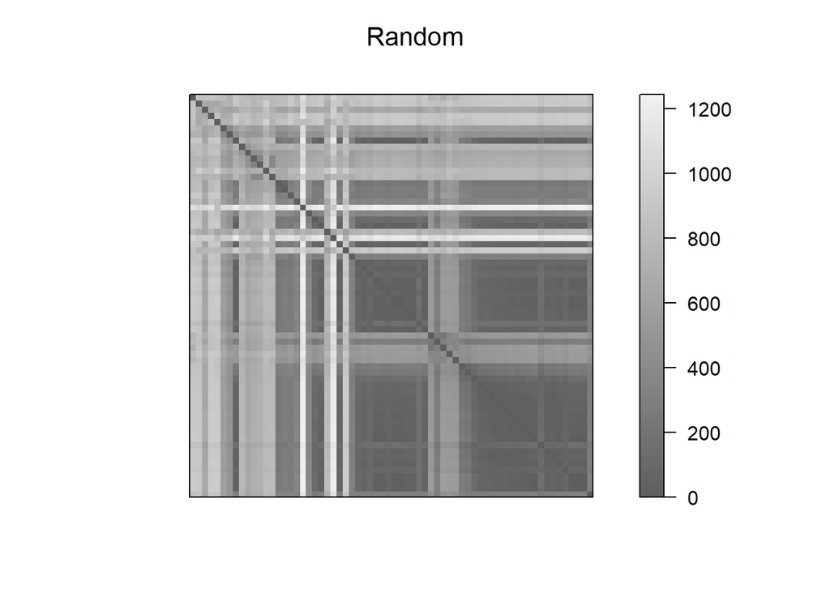

```r
pimage(d,main="Random")
```

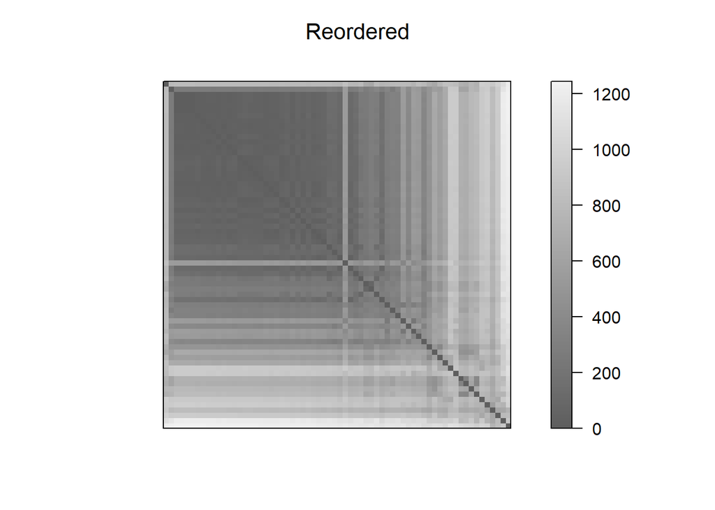

```r
pimage(d,ser,main="Reordered")
```

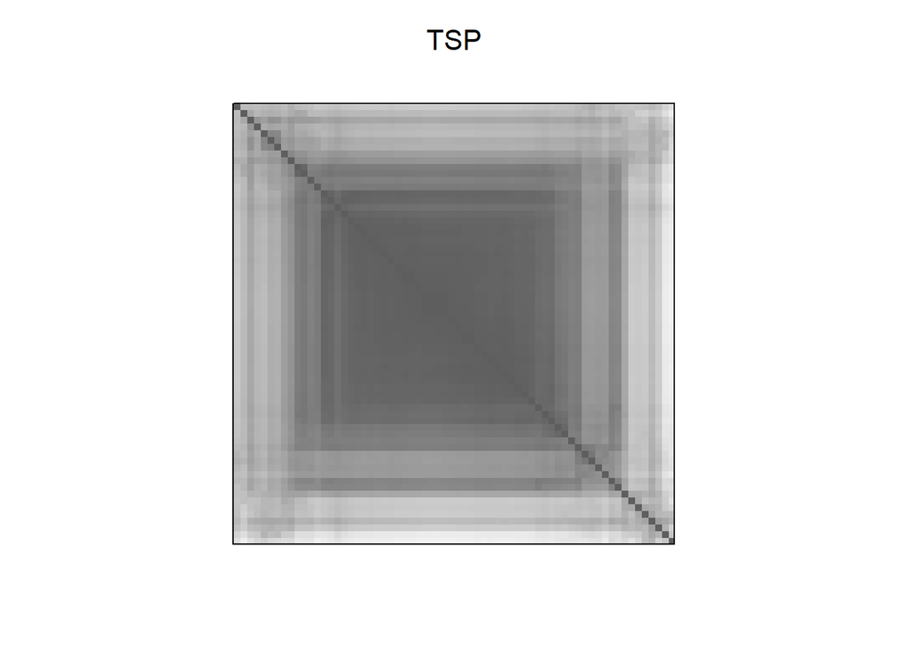

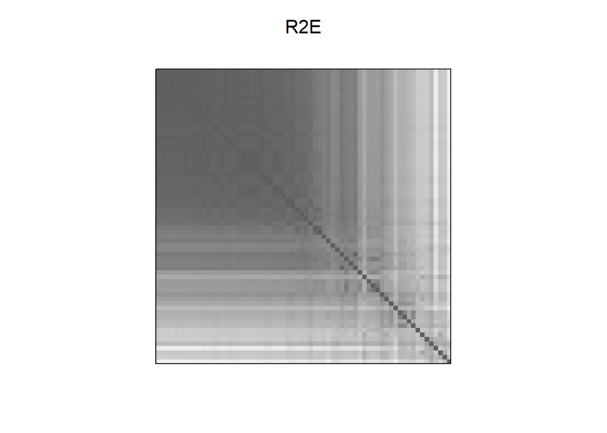

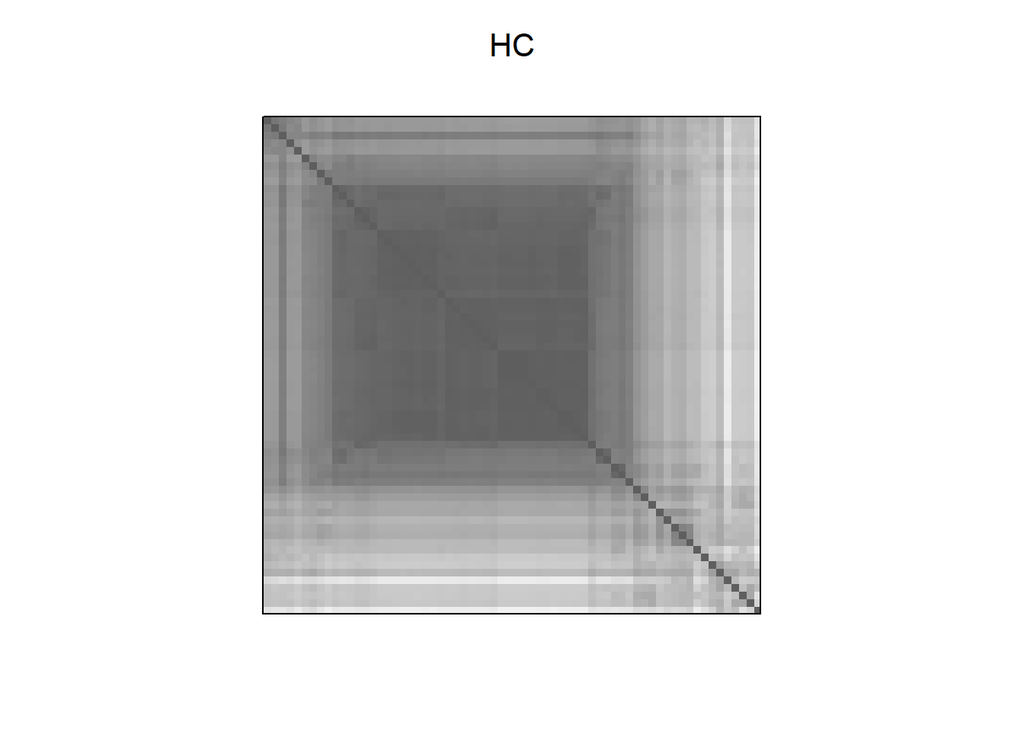

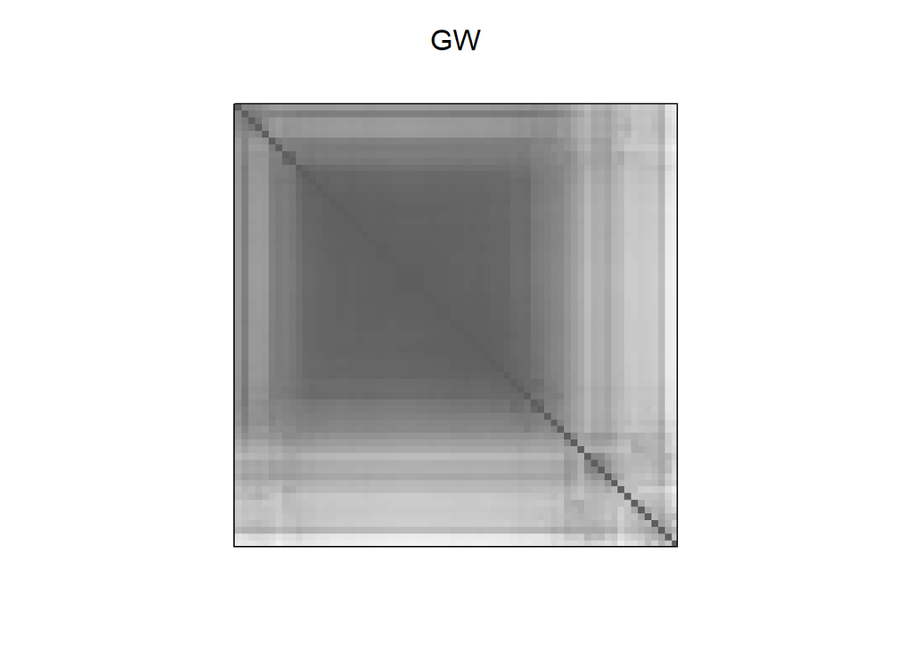

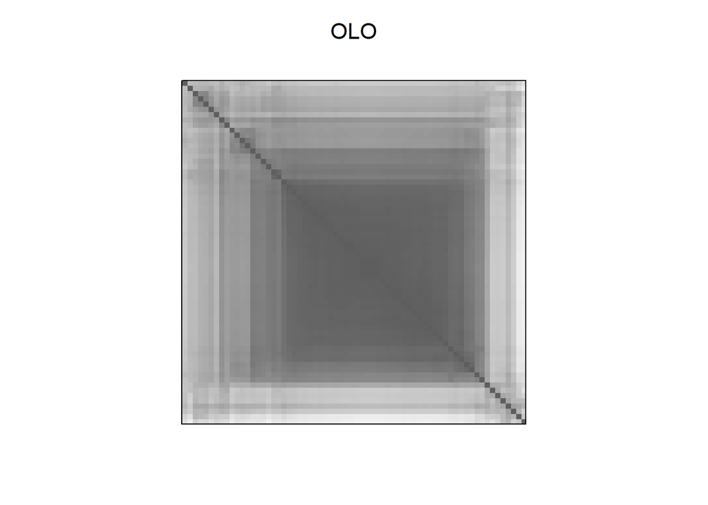

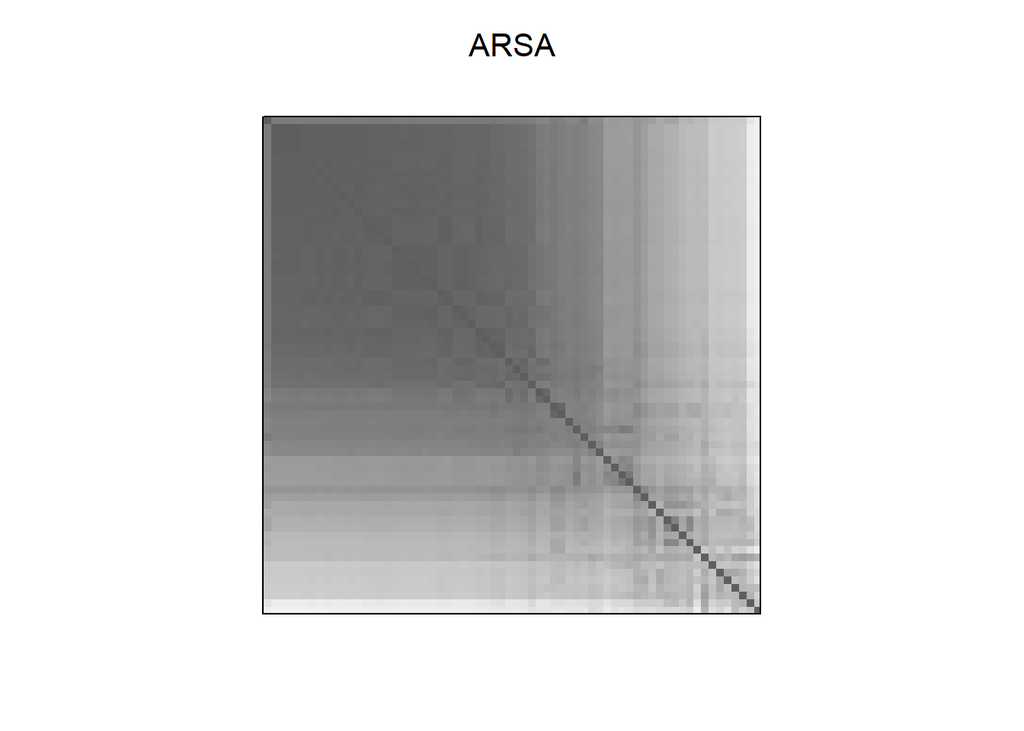

```r
methods <- c("TSP", "R2E", "HC", "GW", "OLO", "ARSA")
ser <- sapply(methods, FUN = function(m) seriate(d,m))
ser <- ser_align(ser)
for(s in ser) pimage(d,s, main=get_method(s), key=FALSE)
```

```r
crit <- sapply(ser, FUN = function(x) criterion(d, x))
t(crit)
```

```
##          2SUM AR_deviations AR_events     BAR     Cor_R Gradient_raw
## TSP  7737.971     1022326.8     20407 1618524 0.8633125        50706
## R2E  7984.422      526760.1     14412 1678230 0.8849202        62696
## HC   8361.324      897262.3     24240 1667144 0.8547193        43040
## GW   7718.532      857263.6     20732 1636899 0.8668733        50056
## OLO  7719.793     1048249.0     21929 1637067 0.8638980        47662
## ARSA 7828.307      316499.7     11537 1654598 0.8852351        68446
##      Gradient_weighted    Inertia Lazy_path_length Least_squares       LS
## TSP           16601582 2103539204         434097.7    1358820071 78302497
## R2E           18143030 2189072869         287462.6    1356764807 77274865
## HC            16866694 2124993881         356627.9    1358466589 78125756
## GW            16919460 2123627244         308403.5    1358396234 78090578
## OLO           16412403 2098781750         501003.4    1359072310 78428616
## ARSA          18569952 2205206983         270657.2    1356195578 76990250
##            ME Moore_stress Neumann_stress Path_length      RGAR
## TSP  8.943631     737.3428       491.3759    15022.37 0.2229786
## R2E  6.060502     751.0186       502.7490    17991.36 0.1574738
## HC   8.196966     742.4939       494.3617    16546.34 0.2648601
## GW   8.960328     737.2333       491.3085    15410.24 0.2265297
## OLO  8.999511     736.9642       491.1523    14966.35 0.2396088
## ARSA 7.293863     745.9239       497.9726    17602.32 0.1260599
```

Hamiltonian path length is minimized with the “OLO” method. We will check the order of the books using the seriation model using that method.

```r
ser.order <- seriate(d,method = "OLO")
get_order(ser.order)
```

```
##  [1] 19 24 26 23  5  2  4  3 20 18 45 46 47 58 21 62 48 49 50 51 52 60 54
## [24] 59 55 53 61 56 65 57 63 64 31 34 35 22  8 32 37 39 36 29 33 25 28 30
## [47] 38 16 15 17 27 66 41 40 42 44 43  6  7  9 10 11 12 14 13  1
```

### Association

Assocation is a little bit clearer on how it can help with this dataset. We can check what testament or section the book belongs to based on the conditional probability of the different words in the book. In other words, we can give a probability of a book being “Book01” (as defined in my PCA dataset) given that “jehovah,” “god”, and “praise” appear in that book. The following is code that will show some of the association rules that we find in the bible.

```r
dtms <- removeSparseTerms(dtm, 0.2)
dtms.m <- as.matrix(dtms)
dtms.m <- t(dtms.m)
assoc <- as(dtms.m,"transactions")
```

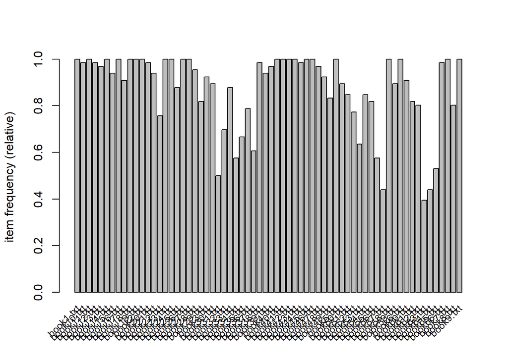

```r
itemFrequencyPlot(assoc[, itemFrequency(assoc) > 0.1], cex.names = 0.8)
```

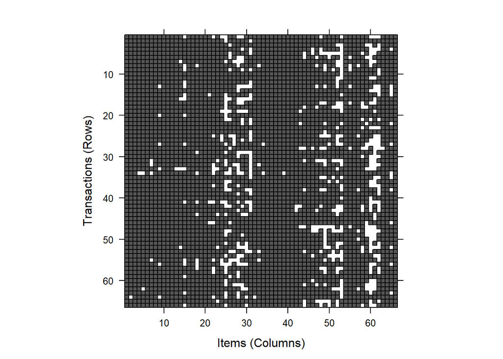

```r
image(assoc, method = NULL, measure = "support", shading = "lift", interactive = FALSE, data = NULL, control = NULL, engine = "default")
```

```r
#rules <- apriori(assoc, parameter = list(support = 0.9, confidence = 0.6))
#rules.sort <- sort(rules, by="confidence")
#inspect(rules.sort[1:3,])
#plot(rules)
```

I can’t for the life of me get the rules small enough to compute without making everything in the dataset = 1. Since everything belongs to everything, everything belongs to nothing in other words. If things had gone correctly, there would be a list of words commonly found together that would give us a better probability of whether or not that book belongs in that testament.

### Word Plots

For fun to see what the most common words in the bible (that have any meaning) are.

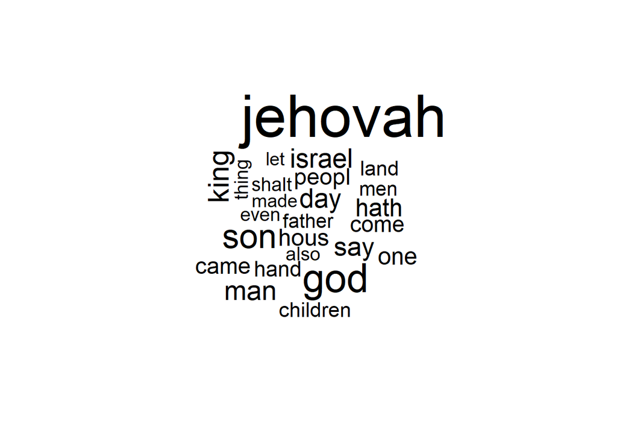

```r
wordcloud(names(freq), freq, max.words=25)
```